# basicR4FOOD

- Program
- Installation of R and Rstudio
- Datasets
- Additional material
  - Notes from the *Data Analysis in Food Science* course
  - Cheatsheets
  - Videos
- Import data
- Summary stats
- Simple plots with ggplot2

Course materiale for intensive R course at Dept FOOD UPCH

# Program

**Where**: Copenhagen Plant Science Center aud 1 (CPSC1)

**When**: Tuesday, January 22nd, 2019

**10-11** : R environment, Import data, data.frame as the *golden object*, simple plot (hist())

**11-12** : Descriptives (table(), aggregate())

**12-13** : Lunch and Data-social

**13-14** : ggplot2 [scatterplots, barcharts, boxplot, jitter]

**14-15** : linear models and t.test

**15-16** : PCA with ggbiplot and extraction of scores/loads -> into data.frame and ggplot2 plots

# Installation of R and Rstudio

Take a look in the file [installation_guide](https://github.com/mortenarendt/basicR4FOOD/blob/master/Installation_guide.pdf)

# Datasets

Datasets for this course is included the dataset folder /data

- **Coffee temp** (Temperature_Coffee.xlsx): A sensorical panel accessing the sensory properties of coffee brewed at different temperatures.
- **GC-Cheese** (cheese_aromas.xlsx): Aromaprofiling of chesses produces under different conditions over different storage times.
- **Mouse** (Mouse_diet_intervention.xlsx): Dietary effects of whey, casein as well as high low fat diet on growth and biomarkers in a mice model.

# Additional material

## Notes from the *Data Analysis in Food Science* course

There is a lot of online available material on statistics using R. The [Notes for Data Analysis in Food Science](https://github.com/mortenarendt/basicR4FOOD/blob/master/Notes_FDA.pdf) covers basic data analysis in eight weeks. Data for most of the content there is to be found [here](https://github.com/mortenarendt/DataAnalysisinFoodScience/) and can be downloaded directly in R using the *devtools* package:

```r
devtools::install_github('mortenarendt/DataAnalysisinFoodScience')
library(DAinFoodScience)
data("maramaox")
```

## Cheatsheets

RStudio has made available [Cheatsheets](https://www.rstudio.com/resources/cheatsheets/) covering the utility of different packages, such as *ggplot2*. These are very condensed, but also very usefull for checking out what you can do with a particular package.

## Videos

For the *Data Analysis in Food Science* course, there is a bunch of videos available going through theory and *How to* in R. These can be found on youtube [here](https://www.youtube.com/playlist?list=PL4L59zaizb3FmBdxuDLRdzGsknTrZN6Ys).

# Import data

Download the excel datafiles to an appropriate location on your computer. Further, install the *rio* package (This you only need to do once).

```r
install.packages('rio')
```

Make a script containing the stuff below, save the file in the same place as the data, and set the working directory to the source file location using Session > Set Working Directory.

```r
library(rio)
X <- import('data/Temperature_Coffee.xlsx')
```

This dataset contains a total of 192 observations. That is data from a sensory panel of 8 assessors (*Assessor* variabel in the dataframe X), across 6 products - coffee at six different brewing temperatures (*Sample* in the dataframe X), in 4 replicates (*Replicate* in X), assessed on 8 attributes: *Intensity*, *Sour*, *Bitter*, *Sweet*, *Tobacco*, *Roasted*, *Nutty* and *Chocolate* represented as individual columns in X. These attributes are all scored on a 0 to 15 scale.

# Summary stats

Lets calculate the mean for the attribute *Intensity* (one of the variables in the dataset) for each temperature setting

```r
aggregate(X$Intensity, list(X$Sample),mean)
```

```
##   Group.1         x
## 1     31C  8.306250
## 2     37C  8.620313
## 3     44C  8.517188
## 4     50C 10.528125
## 5     56C  9.946875
## 6     62C 10.110938
```

... Now lets do it for all attributes.

```r
aggregate(X, list(X$Sample),mean)
```

```
##   Group.1 Sample Assessor Replicate Intensity     Sour    Bitter    Sweet
## 1     31C     NA      4.5       2.5  8.306250 8.451562  9.487500 3.285938
## 2     37C     NA      4.5       2.5  8.620313 9.075000  8.873437 4.143750
## 3     44C     NA      4.5       2.5  8.517188 7.087500  9.281250 4.659375
## 4     50C     NA      4.5       2.5 10.528125 7.589062 10.115625 3.046875
## 5     56C     NA      4.5       2.5  9.946875 8.268750 10.598437 2.868750
## 6     62C     NA      4.5       2.5 10.110938 7.790625  9.632812 3.314062
##     Tobacco  Roasted    Nutty Chocolate
## 1 10.420312 7.884375 3.829687  8.057813
## 2  9.979688 8.695312 3.914062  7.650000
## 3  8.878125 8.882812 4.410938  7.856250
## 4  9.529687 9.660937 4.743750  7.659375
## 5 10.120313 9.693750 3.829687  6.820312
## 6  8.835938 9.787500 4.195312  6.510937
```

... And lets get some more summary stats returned as well

```r
aggregate(X, list(X$Sample),function(x) c(length(x), mean(x), sd(x)))
```

```
##   Group.1 Sample.1 Sample.2 Sample.3 Assessor.1 Assessor.2 Assessor.3
## 1     31C       32       NA       NA  32.000000   4.500000   2.327951
## 2     37C       32       NA       NA  32.000000   4.500000   2.327951
## 3     44C       32       NA       NA  32.000000   4.500000   2.327951
## 4     50C       32       NA       NA  32.000000   4.500000   2.327951
## 5     56C       32       NA       NA  32.000000   4.500000   2.327951
## 6     62C       32       NA       NA  32.000000   4.500000   2.327951
##   Replicate.1 Replicate.2 Replicate.3 Intensity.1 Intensity.2 Intensity.3
## 1   32.000000    2.500000    1.135924   32.000000    8.306250    2.749479
## 2   32.000000    2.500000    1.135924   32.000000    8.620313    2.452052
## 3   32.000000    2.500000    1.135924   32.000000    8.517188    2.780450
## 4   32.000000    2.500000    1.135924   32.000000   10.528125    2.399225
## 5   32.000000    2.500000    1.135924   32.000000    9.946875    2.325800
## 6   32.000000    2.500000    1.135924   32.000000   10.110938    2.625549
##      Sour.1    Sour.2    Sour.3  Bitter.1  Bitter.2  Bitter.3   Sweet.1
```

[output cut: 27 more lines]

# Simple plots with ggplot2

First, import the package *ggplot2*

```r
install.packages('ggplot2')
```

Now let's make a plot of the Intensity (on the y-axis) versus the temperature (on the x-axis) and color all the responses according to the Assessor

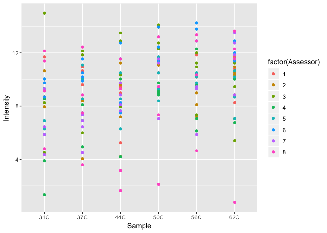

```r
library(ggplot2)
ggplot(data = X, aes(Sample, Intensity, color = factor(Assessor))) +
  geom_point()
```

Now, lets join the points within each assessor (and replicate), and further, plot each replicate in its own panel.

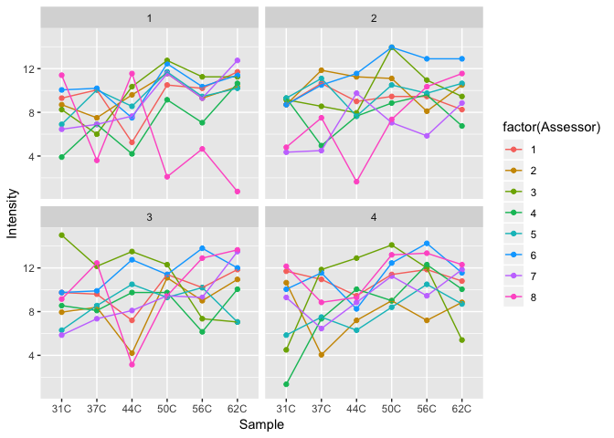

```r
ggplot(data = X, aes(Sample, Intensity, color = factor(Assessor), group = factor(Assessor))) +
  geom_point() + geom_line() +
  facet_wrap(~Replicate)
```

Instead of the raw data you might want to see the means of each design cell (temperature and assessor). We can calculate that as described above with aggregate() - and plot it!

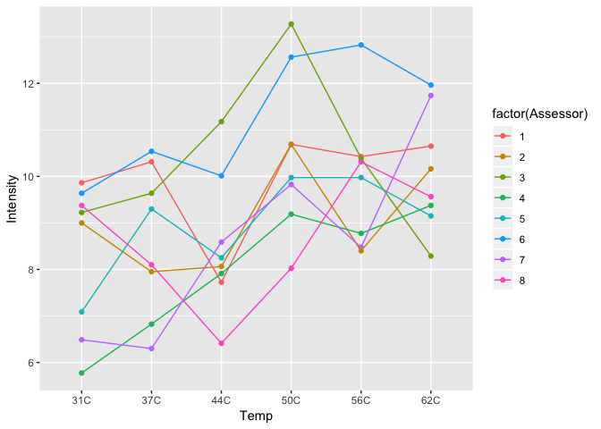

```r
Xm <- aggregate(X, list(X$Sample, X$Assessor),mean)
colnames(Xm)[1] <- 'Temp'
ggplot(data = Xm, aes(Temp, Intensity, color = factor(Assessor), group = factor(Assessor))) +
  geom_point() + geom_line()
```